# NYPD Shooting

RM

2022-05-08

## Import NYPD shooting dataset

This is the step where the NYPD shooting data set (csv format) is retrieved from https://catalog.data.gov/dataset/nypd-shooting-incident-data-historic.

```r
# Put the link containing NYPD shooting data in a variable
url <- "https://data.cityofnewyork.us/api/views/833y-fsy8/rows.csv?accessType=DOWNLOAD"

# Importing the NYPD shooting data
nypd_shooting <- read.csv(url)
```

## Initial look at the data

The next step is to look at the summarized data:

```r
summary(nypd_shooting)
```

```
##   INCIDENT_KEY        OCCUR_DATE         OCCUR_TIME            BORO
##  Min.   :  9953245   Length:23585       Length:23585       Length:23585
##  1st Qu.: 55322804   Class :character   Class :character   Class :character
##  Median : 83435362   Mode  :character   Mode  :character   Mode  :character
##  Mean   :102280741
##  3rd Qu.:150911774
##  Max.   :230611229
##
##     PRECINCT      JURISDICTION_CODE LOCATION_DESC      STATISTICAL_MURDER_FLAG
##  Min.   :  1.00   Min.   :0.000     Length:23585       Length:23585
##  1st Qu.: 44.00   1st Qu.:0.000     Class :character   Class :character
##  Median : 69.00   Median :0.000     Mode  :character   Mode  :character
##  Mean   : 66.21   Mean   :0.333
##  3rd Qu.: 81.00   3rd Qu.:0.000
##  Max.   :123.00   Max.   :2.000
##                   NA's   :2
##  PERP_AGE_GROUP       PERP_SEX          PERP_RACE         VIC_AGE_GROUP
##  Length:23585       Length:23585       Length:23585       Length:23585
##  Class :character   Class :character   Class :character   Class :character
##  Mode  :character   Mode  :character   Mode  :character   Mode  :character
##
##
##
##
##    VIC_SEX            VIC_RACE           X_COORD_CD        Y_COORD_CD
##  Length:23585       Length:23585       Min.   : 914928   Min.   :125757
##  Class :character   Class :character   1st Qu.: 999925   1st Qu.:182539
##  Mode  :character   Mode  :character   Median :1007654   Median :193470
##                                        Mean   :1009379   Mean   :207300
##                                        3rd Qu.:1016782   3rd Qu.:239163
##                                        Max.   :1066815   Max.   :271128
##
##     Latitude       Longitude        Lon_Lat
##  Min.   :40.51   Min.   :-74.25   Length:23585
##  1st Qu.:40.67   1st Qu.:-73.94   Class :character
##  Median :40.70   Median :-73.92   Mode  :character
##  Mean   :40.74   Mean   :-73.91
##  3rd Qu.:40.82   3rd Qu.:-73.88
##  Max.   :40.91   Max.   :-73.70
##
```

## Data transformation

To get a better view of the NYPD shooting data set I transform the following variables to factors:

- INCIDENT_KEY
- PRECINCT
- JURISDICTION_CODE
- BORO
- LOCATION_DESC
- STATISTICAL_MURDER_FLAG
- PERP_AGE_GROUP
- PERP_SEX
- PERP_RACE
- VIC_AGE_GROUP
- VIC_SEX
- VIC_RACE

After that I remove the variables I don’t need:

- X_COORD_CD
- Y_COORD_CD
- Latitude
- Longitude
- Lon_Lat

The final step in this first phase is transforming the variables containing a date (OCCUR_DATE) and time (OCCUR_TIME) into actual date and time variables.

```r
# transform variables with data type character to factors
nypd_shooting_transform <- nypd_shooting %>%
  mutate(INCIDENT_KEY = as.factor(INCIDENT_KEY),
         PRECINCT = as.factor(PRECINCT),
         JURISDICTION_CODE = as.factor(JURISDICTION_CODE),
         BORO = as.factor(BORO),
         LOCATION_DESC = as.factor(LOCATION_DESC),
         STATISTICAL_MURDER_FLAG = as.factor(STATISTICAL_MURDER_FLAG),
         PERP_AGE_GROUP = as.factor(PERP_AGE_GROUP),
         PERP_SEX = as.factor(PERP_SEX),
         PERP_RACE = as.factor(PERP_RACE),
         VIC_AGE_GROUP = as.factor(VIC_AGE_GROUP),
         VIC_SEX = as.factor(VIC_SEX),
         VIC_RACE = as.factor(VIC_RACE))

# Remove variables I don't need
nypd_shooting_transform_I <- nypd_shooting_transform %>%
  select(-c(X_COORD_CD, Y_COORD_CD, Latitude, Longitude, Lon_Lat))

# Transform variables containing date and time into actual date and time variables
nypd_shooting_transform_II <- nypd_shooting_transform_I %>%
  mutate(OCCUR_DATE = mdy(OCCUR_DATE),
         OCCUR_TIME = hms(OCCUR_TIME))

summary(nypd_shooting_transform_II)
```

```
##     INCIDENT_KEY     OCCUR_DATE           OCCUR_TIME
##  173354054:   18   Min.   :2006-01-01   Min.   :0S
##  23749375 :   12   1st Qu.:2008-12-31   1st Qu.:3H 20M 0S
##  24717013 :   12   Median :2012-02-27   Median :15H 0M 0S
##  33478089 :   12   Mean   :2012-10-05   Mean   :12H 33M 7.48187407250225S
##  33706902 :   12   3rd Qu.:2016-03-02   3rd Qu.:20H 45M 0S
##  35803777 :   12   Max.   :2020-12-31   Max.   :23H 59M 0S
##  (Other)  :23507
##             BORO         PRECINCT     JURISDICTION_CODE
##  BRONX        :6701   75     : 1375   0   :19629
##  BROOKLYN     :9734   73     : 1284   1   :   54
##  MANHATTAN    :2922   67     : 1101   2   : 3900
##  QUEENS       :3532   79     :  921   NA's:    2
##  STATEN ISLAND: 696   44     :  841
##                       47     :  818
##                       (Other):17245
##                    LOCATION_DESC   STATISTICAL_MURDER_FLAG PERP_AGE_GROUP
##                           :13581   false:19085                    :8295
##  MULTI DWELL - PUBLIC HOUS: 4240   true : 4500             18-24  :5508
##  MULTI DWELL - APT BUILD  : 2553                           25-44  :4714
##  PVT HOUSE                :  857                           UNKNOWN:3148
##  GROCERY/BODEGA           :  574                           <18    :1368
##  BAR/NIGHT CLUB           :  562                           45-64  : 495
##  (Other)                  : 1218                           (Other):  57
##  PERP_SEX           PERP_RACE     VIC_AGE_GROUP   VIC_SEX
##   : 8261   BLACK         :10025   <18    : 2525   F: 2204
##  F:  335                 : 8261   18-24  : 9003   M:21370
##  M:13490   WHITE HISPANIC: 1988   25-44  :10303   U:   11
##  U: 1499   UNKNOWN       : 1836   45-64  : 1541
##            BLACK HISPANIC: 1096   65+    :  154
##            WHITE         :  255   UNKNOWN:   59
##            (Other)       :  124
##                            VIC_RACE
##  AMERICAN INDIAN/ALASKAN NATIVE:    9
##  ASIAN / PACIFIC ISLANDER      :  327
##  BLACK                         :16869
##  BLACK HISPANIC                : 2245
##  UNKNOWN                       :   65
##  WHITE                         :  620
##  WHITE HISPANIC                : 3450
```

Compared to before the transformation, there is more information shown about descriptive statistics of the variables.

## Data cleaning

After transformation of the data it needs to be cleaned. The variable JURISDICTION_CODE has 2 NA’s:

```r
 nypd_shooting_transform_II[is.na(nypd_shooting_transform_II$JURISDICTION_CODE),]
```

```
##       INCIDENT_KEY OCCUR_DATE OCCUR_TIME      BORO PRECINCT JURISDICTION_CODE
## 17694     33110745 2007-07-13  1H 10M 0S    QUEENS      104              <NA>
## 21903    194525846 2019-03-09  2H 41M 0S MANHATTAN       25              <NA>
##                   LOCATION_DESC STATISTICAL_MURDER_FLAG PERP_AGE_GROUP PERP_SEX
## 17694 SOCIAL CLUB/POLICY LOCATI                   false            <18        M
## 21903                                             false        UNKNOWN        M
##            PERP_RACE VIC_AGE_GROUP VIC_SEX       VIC_RACE
## 17694 WHITE HISPANIC         18-24       M WHITE HISPANIC
## 21903          BLACK         25-44       M          BLACK
```

Because it is impossible to know what the JURISDICTION_CODE value for these 2 observations should be, I will remove them.

```r
# Remove 2 NA's (variable JURISDICTION_CODE) from the NYPD Shooting dataset
nypd_cleaning <- na.omit(nypd_shooting_transform_II)

# Summary of data after removal 2 NA's
summary(nypd_cleaning$JURISDICTION_CODE)
```

```
##     0     1     2
## 19629    54  3900
```

The summary of the variables shows that the variable OCCUR_TIME has a minimum value of 0 seconds. This could be a data error or given the format of OCCUR_TIME it could be midnight. I plotted the hours (values ranging from 0 to 23) of OCCUR_TIME to discover this.

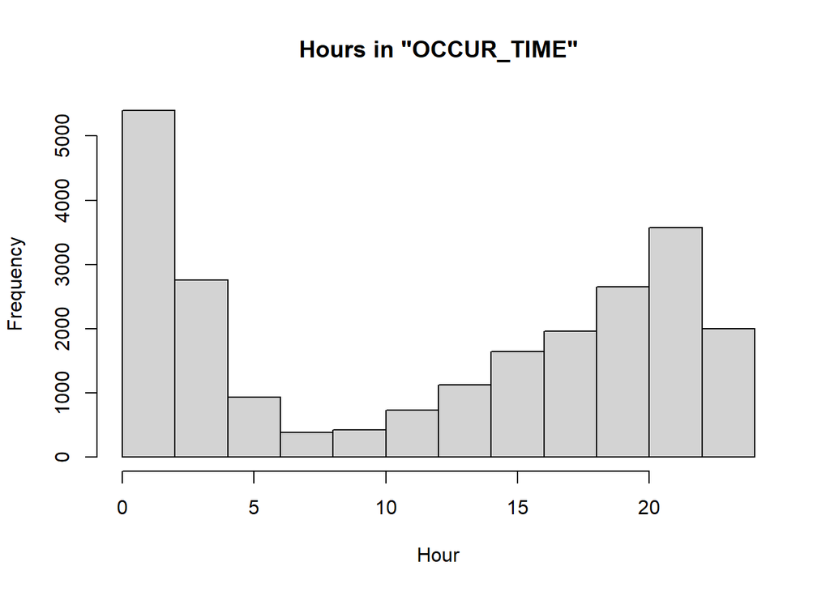

```r
# Count the frequency of hours in OCCUR_TIME
count_hours_hist <- nypd_cleaning %>%
  mutate(Hour = hour(OCCUR_TIME)) %>%
  select(Hour) %>%
  mutate(Hour_num = as.numeric(Hour))

# Histogram of frequency of hours in OCCUR_TIME
hist(count_hours_hist$Hour_num, xlab = 'Hour', main = 'Hours in "OCCUR_TIME"')
```

The distribution of hours in OCCUR_TIME looks normal. I think it is more likely that most of the shootings occur when it’s dark (late nights and early mornings) than that OCCUR_TIME contains errors.

## Missing values

Besides JURISDICTION_CODE there are a few variables which have multiple forms of missing values (The value ‘Unknown’ and blank spaces).

- LOCATION_DESC
- PERP_AGE_GROUP
- PERP_SEX
- PERP_RACE

#### LOCATION_COUNT

```r
# Count of all of the locations which occur at least 175 times
Location_count <- nypd_cleaning %>%
  select(LOCATION_DESC) %>%
  group_by(LOCATION_DESC) %>%
  summarise(Count = n()) %>%
  filter(Count >= 175) %>%
  arrange(desc(Count))

knitr::kable(Location_count, align = 'l')
```

| LOCATION_DESC | Count |
| --- | --- |
|  | 13580 |
| MULTI DWELL - PUBLIC HOUS | 4240 |
| MULTI DWELL - APT BUILD | 2553 |
| PVT HOUSE | 857 |
| GROCERY/BODEGA | 574 |
| BAR/NIGHT CLUB | 562 |
| COMMERCIAL BLDG | 234 |
| RESTAURANT/DINER | 188 |
| NONE | 175 |

The variable LOCATION_COUNT has values containing an empty space (13.580) and values containing ‘NONE’ (175). Because the values containing an empty space total more than half of the entire data set it would be unfeasible to remove all of these values.

There are far fewer values containing the value ‘None’. A quick glance at this subset of data reveals that the only similarity among these cases is that they are all from 2006.

```r
# Show that all of the 'NONE' Values are from 2006
LOCATION_NONE <- nypd_cleaning %>%
  filter(LOCATION_DESC == 'NONE' ) %>%
  select(OCCUR_DATE, LOCATION_DESC) %>%
  mutate(Year = year(OCCUR_DATE)) %>%
  select(Year, LOCATION_DESC) %>%
  group_by(Year, LOCATION_DESC) %>%
  summarise(Frequency = n())

knitr::kable(LOCATION_NONE, align = 'l')
```

| Year | LOCATION_DESC | Frequency |
| --- | --- | --- |
| 2006 | NONE | 175 |

I will recode the blank spaces of the variable LOCATION_DESC to ‘NONE’. Because the variable is a description of the location, recoding from a blank space tot ‘NONE’ won’t change the lack of information of these observations.

```r
# Recode blank spaces of LOCATION_DESC to 'NONE'
nypd_recode <- nypd_cleaning %>%
  mutate(LOCATION_DESC = if_else(nypd_cleaning$LOCATION_DESC == "" , "NONE",
                                 as.character(nypd_cleaning$LOCATION_DESC))) %>%
  mutate(LOCATION_DESC = as.factor(LOCATION_DESC))

summary(nypd_recode$LOCATION_DESC)
```

```
##                       ATM                      BANK            BAR/NIGHT CLUB
##                         1                         1                       562
##         BEAUTY/NAIL SALON               CANDY STORE               CHAIN STORE
##                       100                         6                         5
##                CHECK CASH         CLOTHING BOUTIQUE           COMMERCIAL BLDG
##                         1                        14                       234
##                DEPT STORE            DOCTOR/DENTIST                DRUG STORE
##                         5                         1                        11
##       DRY CLEANER/LAUNDRY         FACTORY/WAREHOUSE                 FAST FOOD
##                        30                         6                        98
##               GAS STATION            GROCERY/BODEGA      GYM/FITNESS FACILITY
##                        53                       574                         3
##                  HOSPITAL               HOTEL/MOTEL             JEWELRY STORE
##                        38                        24                        12
##              LIQUOR STORE              LOAN COMPANY   MULTI DWELL - APT BUILD
##                        36                         1                      2553
## MULTI DWELL - PUBLIC HOUS                      NONE          PHOTO/COPY STORE
##                      4240                     13755                         1
##                 PVT HOUSE          RESTAURANT/DINER                    SCHOOL
##                       857                       188                         1
##                SHOE STORE            SMALL MERCHANT SOCIAL CLUB/POLICY LOCATI
##                         9                        25                        65
##          STORAGE FACILITY        STORE UNCLASSIFIED               SUPERMARKET
##                         1                        35                        19
##           TELECOMM. STORE             VARIETY STORE               VIDEO STORE
##                         5                        11                         2
```

#### PERP_AGE_GROUP

The distribution of the variable PERP_AGE_GROUP is:

```r
summary(nypd_recode$PERP_AGE_GROUP)
```

```
##             <18    1020   18-24     224   25-44   45-64     65+     940 UNKNOWN
##    8295    1367       1    5508       1    4714     495      54       1    3147
```

There are three strange values with one observation: ‘1020’, ‘224’, ‘940’.

```r
# Show observations with strange values for PERP_AGE_GROUP
strange_value <- nypd_recode %>%
  filter(PERP_AGE_GROUP =='1020' | PERP_AGE_GROUP =='224' | PERP_AGE_GROUP =='940')

strange_value
```

```
##   INCIDENT_KEY OCCUR_DATE OCCUR_TIME     BORO PRECINCT JURISDICTION_CODE
## 1    142247967 2015-04-19   2H 5M 0S    BRONX       47                 2
## 2     89595619 2013-03-12 20H 28M 0S BROOKLYN       90                 0
## 3     71625599 2010-03-06  4H 14M 0S    BRONX       41                 0
##               LOCATION_DESC STATISTICAL_MURDER_FLAG PERP_AGE_GROUP PERP_SEX
## 1 MULTI DWELL - PUBLIC HOUS                   false           1020        M
## 2               GAS STATION                   false            940        M
## 3            BAR/NIGHT CLUB                   false            224        M
##        PERP_RACE VIC_AGE_GROUP VIC_SEX       VIC_RACE
## 1          BLACK         25-44       M          BLACK
## 2 WHITE HISPANIC         25-44       M WHITE HISPANIC
## 3 WHITE HISPANIC         18-24       M WHITE HISPANIC
```

The observations show that only these three values for PERP_AGE_GROUP are odd. Therefore I will recode these values to ‘UNKNOWN’.

```r
# Recode odd values of PERP_AGE_GROUP to 'UNKNOWN'
nypd_recode_I <- nypd_recode %>%
  mutate(PERP_AGE_GROUP = if_else(PERP_AGE_GROUP =='1020' | PERP_AGE_GROUP =='224' | PERP_AGE_GROUP =='940', "UNKNOWN",as.character(PERP_AGE_GROUP))) %>%
  mutate(PERP_AGE_GROUP = as.factor(PERP_AGE_GROUP))

summary(nypd_recode_I$PERP_AGE_GROUP)
```

```
##             <18   18-24   25-44   45-64     65+ UNKNOWN
##    8295    1367    5508    4714     495      54    3150
```

Just as with LOCATION_COUNT, PERP_AGE_GROUP has blank spaces and ‘UNKNOWN’ values. There are too many observations of both to simply delete them. Also, recoding the blank spaces to ‘UNKNOWN’ won’t decrease the degree of information of PERP_AGE_GROUP. Thus, this is the next step.

```r
# Recode blank spaces of PERP_AGE_GROUP to 'UNKNOWN'
nypd_recode_II <- nypd_recode_I %>%
  mutate(PERP_AGE_GROUP = if_else(PERP_AGE_GROUP == "", "UNKNOWN", as.character(PERP_AGE_GROUP))) %>%
  mutate(PERP_AGE_GROUP = as.factor(PERP_AGE_GROUP))

summary(nypd_recode_II$PERP_AGE_GROUP)
```

```
##     <18   18-24   25-44   45-64     65+ UNKNOWN
##    1367    5508    4714     495      54   11445
```

#### PERP_SEX

Besides male and female, the variable PERP_SEX has observations with blank spaces and ‘U’ as values.

```r
summary(nypd_recode_II$PERP_SEX)
```

```
##           F     M     U
##  8261   335 13488  1499
```

The value ‘U’ could stand for ‘Unknown’ but it could also mean a number of other things (‘Undefined’, ‘Unisex’). To get a better view of what it might mean I looked at the earliest and the latest date an observation had the value ‘U’ for PERP_SEX.

```r
# Look at the earliest and latest date for entries where PERP_SEX equals 'U'
U_date <-nypd_recode_II %>%
    group_by(PERP_SEX) %>%
    summarise(min_date = min(OCCUR_DATE), max_date = max(OCCUR_DATE)) %>%
    filter(PERP_SEX == 'U')

knitr::kable(U_date, align = 'l')
```

| PERP_SEX | min_date | max_date |
| --- | --- | --- |
| U | 2006-01-01 | 2019-12-18 |

Because the range of dates is from 2006 to 2019 (And not a shorter time period like 2018 to 2019) I feel comfortable with the assumption that ‘U’ equals ‘Unknown’.

The next step for PERP_SEX is to convert the blank spaces to ‘U’. Again, recoding this won’t decrease the amount of information for this variable.

```r
# Recode blank spaces of PERP_SEX to 'U'
nypd_recode_III <- nypd_recode_II %>%
  mutate(PERP_SEX = if_else(PERP_SEX == "", "U", as.character(PERP_SEX))) %>%
  mutate(PERP_SEX = as.factor(PERP_SEX))

summary(nypd_recode_III$PERP_SEX)
```

```
##     F     M     U
##   335 13488  9760
```

#### PERP_RACE

The distribution for PERP_RACE is:

```r
summary(nypd_recode_III$PERP_RACE)
```

```
##                                AMERICAN INDIAN/ALASKAN NATIVE
##                           8261                              2
##       ASIAN / PACIFIC ISLANDER                          BLACK
##                            122                          10024
##                 BLACK HISPANIC                        UNKNOWN
##                           1096                           1836
##                          WHITE                 WHITE HISPANIC
##                            255                           1987
```

Again, there are values with blank spaces and ‘UNKNOWN’. I will recode the blank spaces to ‘UNKNOWN’, this won’t detract from the information value of the column.

```r
# Recode blank spaces of PERP_RACE to 'UNKNOWN'
nypd_recode_IV <- nypd_recode_III %>%
  mutate(PERP_RACE = if_else(PERP_RACE == "", "UNKNOWN", as.character(PERP_RACE))) %>%
  mutate(PERP_RACE = as.factor(PERP_RACE))

summary(nypd_recode_IV$PERP_RACE)
```

```
## AMERICAN INDIAN/ALASKAN NATIVE       ASIAN / PACIFIC ISLANDER
##                              2                            122
##                          BLACK                 BLACK HISPANIC
##                          10024                           1096
##                        UNKNOWN                          WHITE
##                          10097                            255
##                 WHITE HISPANIC
##                           1987
```

#### VIC_AGE_GROUP

The values of VIC_AGE_GROUP all look normal (No blank spaces and all unknown values in ‘UNKNOWN’), there are no values that need to be recoded.

```r
summary(nypd_recode_IV$VIC_AGE_GROUP)
```

```
##     <18   18-24   25-44   45-64     65+ UNKNOWN
##    2525    9002   10302    1541     154      59
```

#### VIC_SEX

The values of VIC_SEX all look normal (No blank spaces and all unknown values in ‘UNKNOWN’), there are no values that need to be recoded.

```r
summary(nypd_recode_IV$VIC_SEX)
```

```
##     F     M     U
##  2204 21368    11
```

#### VIC_RACE

The values of VIC_RACE all look normal (No blank spaces and all unknown values in ‘UNKNOWN’), there are no values that need to be recoded.

```r
summary(nypd_recode_IV$VIC_RACE)
```

```
## AMERICAN INDIAN/ALASKAN NATIVE       ASIAN / PACIFIC ISLANDER
##                              9                            327
##                          BLACK                 BLACK HISPANIC
##                          16868                           2245
##                        UNKNOWN                          WHITE
##                             65                            620
##                 WHITE HISPANIC
##                           3449
```

## Visualization and analysis

The first thing I was curious to learn more about was the distribution of shooting cases among New York boroughs:

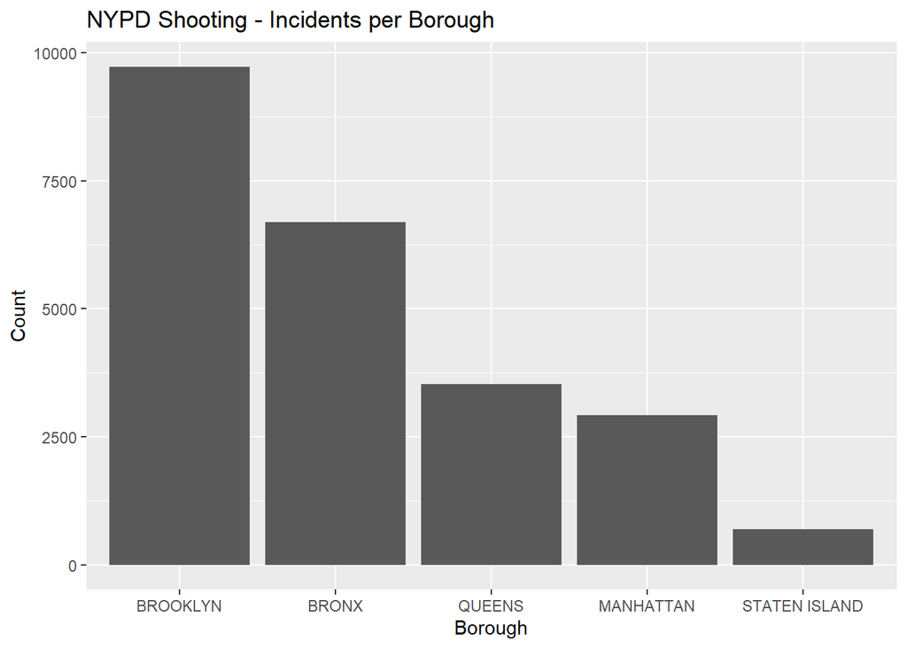

```r
# Number of entries per Borough
viz_I <- nypd_recode_IV %>%
  select(BORO) %>%
  group_by(BORO) %>%
  summarise(Count = n()) %>%
  ggplot(aes(x = reorder(BORO,-Count), y = Count)) +
  geom_bar(stat= "identity") +
  labs(x = 'Borough', y = 'Count', title = 'NYPD Shooting - Incidents per Borough')

viz_I
```

The distribution is interesting, but there is another variable I want to look at: INCIDENT_KEY. The command `summary(nypd_shooting_transform_II)` showed that several incident keys in the NYPD shooting data set appear more than once. To demonstrate this I plotted a histogram of the number of entries in the NYPD shooting data set of single incident keys:

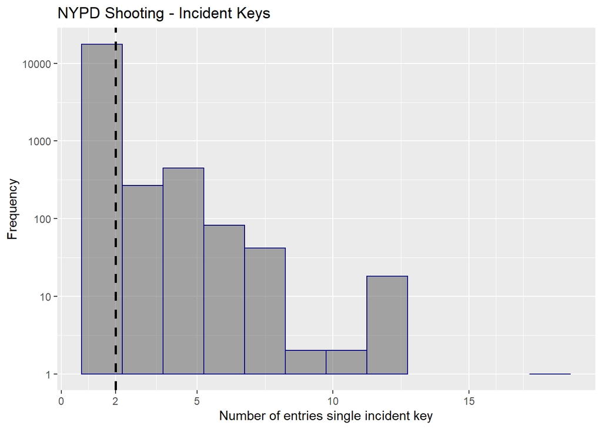

```r
# Number of entries single incident key
viz_II <- nypd_recode_IV %>%
  select(INCIDENT_KEY) %>%
  group_by(INCIDENT_KEY) %>%
  summarise(Count = n()) %>%
  ggplot(aes(Count)) +
  geom_histogram(binwidth = 1.5, color="darkblue", alpha = 0.5) +
  scale_y_log10() +
  scale_x_continuous(breaks=c(0, 2, 5, 10, 15)) +
  geom_vline(xintercept=c(2), linetype="dashed", size = 1) +
  labs(x = 'Number of entries single incident key', y = 'Frequency', title = 'NYPD Shooting - Incident Keys')

viz_II
```

The next plot is nearly identical, but now I only select incident keys which are in the data set more than once:

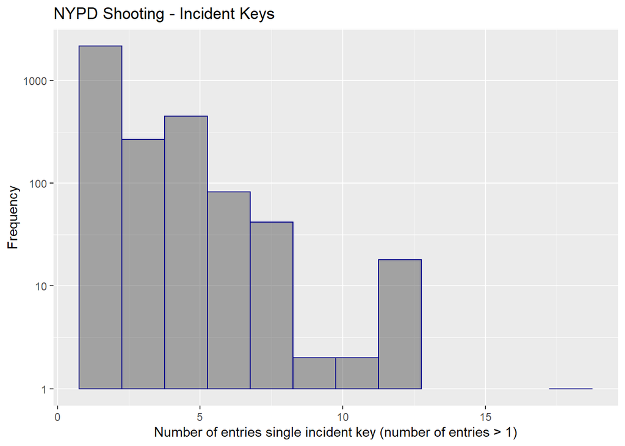

```r
# Number of entries single incident key (number of entries > 1)
viz_III <- nypd_recode_IV %>%
  select(INCIDENT_KEY) %>%
  group_by(INCIDENT_KEY) %>%
  summarise(Count = n()) %>%
  filter(Count > 1) %>%
  ggplot(aes(Count)) +
  geom_histogram(binwidth = 1.5, color="darkblue", alpha = 0.5) +
  scale_y_log10() +
  labs(x = 'Number of entries single incident key (number of entries > 1)', y = 'Frequency', title = 'NYPD Shooting - Incident Keys')

# Total count of single incident keys
total_count <- nypd_recode_IV %>%
  select(INCIDENT_KEY) %>%
  group_by(INCIDENT_KEY) %>%
  summarise(Count = n())

# Total count of single incident keys that appear more than once
gt_1 <- nypd_recode_IV %>%
  select(INCIDENT_KEY) %>%
  group_by(INCIDENT_KEY) %>%
  summarise(Count = n()) %>%
  filter(Count > 1)

# number of incident keys that appear more than once in the NYPD shooting data set
perc <- round(nrow(gt_1)/nrow(total_count) * 100,2)

viz_III
```

To see whether incident keys that appear multiple times affect the number of cases, I decided to plot the decrease in entries before and after removing the duplicate cases. I did this per borough, so I could see whether the number of entries for certain boroughs were affected disproportionately.

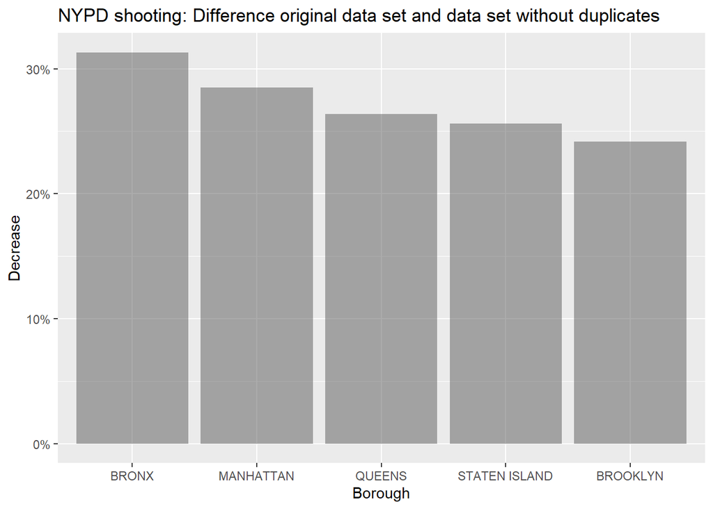

```r
# Select all the incident keys in the NYPD Shooting data set
incident_keys <- nypd_recode_IV %>%
  select(INCIDENT_KEY) %>%
  group_by(INCIDENT_KEY) %>%
  summarise(Count = n()) %>%
  select(INCIDENT_KEY)

# Count all the distinct incident keys in the NYPD Shooting data set (grouped by borough)
incident_key_single <- incident_keys %>%
  left_join(nypd_recode_IV) %>%
  select(INCIDENT_KEY, BORO) %>%
  distinct(INCIDENT_KEY, BORO) %>%
  group_by(BORO) %>%
  summarise(Count = n()) %>%
  mutate(category = "single")

# Count all incident keys in the NYPD Shooting data set (grouped by borough)
incident_key_all <- nypd_recode_IV %>%
  select(BORO) %>%
  group_by(BORO) %>%
  summarise(Count = n()) %>%
  mutate(category = "all")

# Compute the difference between the number of incident keys in the original data set
# and the data set where every incident key appears only once. This is done per borough.
incident_key_total <- incident_key_all %>%
  inner_join(incident_key_single, by = "BORO") %>%
  rename(count_all = Count.x, count_single = Count.y) %>%
  select(BORO, count_all, count_single) %>%
  mutate(difference =  ((count_all - count_single)/ count_single))

# Plot that shows the decrease in observations when all incident keys
# which appear more than once have been removed. This is done per borough.
plot_analysis <- incident_key_total %>%
  ggplot(aes(x= reorder(BORO,-difference), y = difference)) +
  geom_bar(stat= "identity", alpha=0.5) +
  scale_y_continuous(labels = scales::percent) +
  labs(x = 'Borough', y = 'Decrease', title = 'NYPD shooting: Difference original data set and data set without duplicates')

max_decrease <- round(max(incident_key_total$difference) * 100, 2)

min_decrease <- round(min(incident_key_total$difference) * 100, 2)

plot_analysis
```

What is interesting is that the decrease in entries is about the same for all five boroughs. Of course, the difference between the biggest (31.31%) and smallest (24.19%) decrease is not insignificant. However, even when removing all double entries across the five boroughs the original order remains intact:

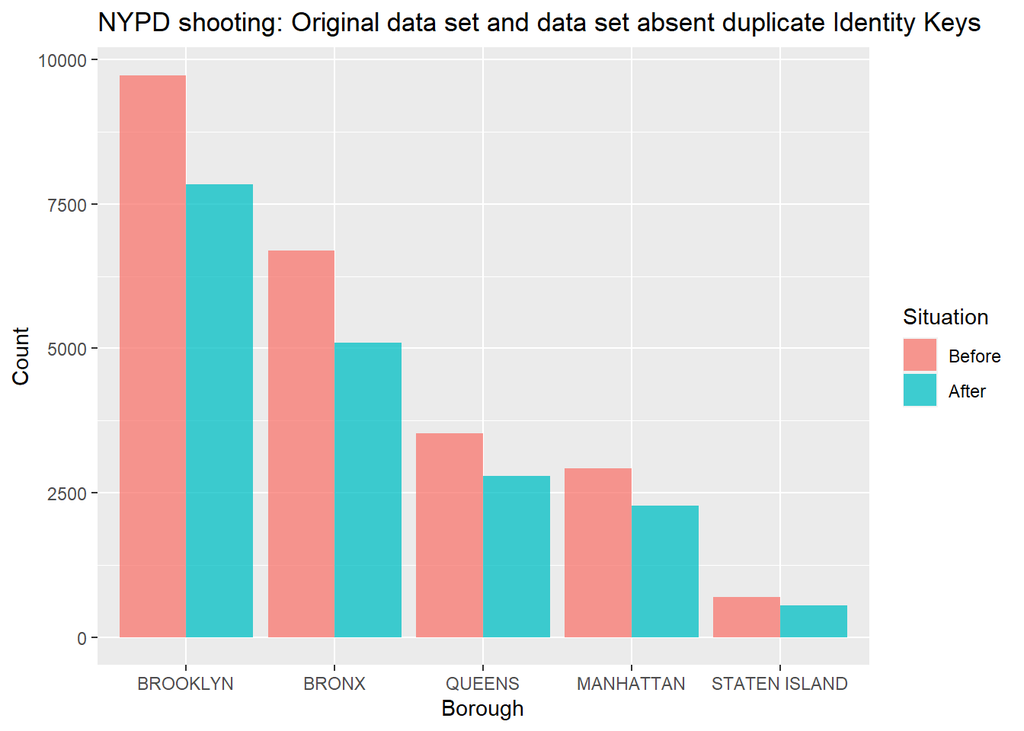

```r
# A plot of the original data set and the data set where all the duplicate identity keys have been removed
incident_key_comp <- incident_key_all %>%
  union(incident_key_single)

i_key_ba <- ggplot(incident_key_comp, aes(fill=category, y=Count, x=reorder(BORO,-Count))) +
  geom_bar(position="dodge", stat="identity", alpha=0.75) +
  scale_fill_hue(labels = c("Before", "After")) +
  labs(x = 'Borough', y = 'Count', title = 'NYPD shooting: Original data set and data set absent duplicate Identity Keys', fill = 'Situation')

i_key_ba
```

## Conclusion

The analysis showed that an eventual removal of incident keys that appear more than once will not change which boroughs are featured most often. It does however, lead to additional questions. For instance, this analysis could also be applied to the precincts: Does removal of double incident keys lead to a change in which precincts appear the most in the NYPD shooting data set?

Also, the section ‘Missing values’ is dedicated to recoding empty values to ‘Unknown’. It would be interesting to find out whether the amount of ‘Unknown’ differs among the boroughs and precincts in the NYPD data set.

### Bias

A possible source of bias could have been the final visualization in this document (‘NYPD shooting: Original data set and data set absent duplicates’). It appears that after removing double incident keys the decrease in entries for Brooklyn and the Bronx is much higher than Queens, Manhattan and Staten Island. To me, it looked like Brooklyn and the Bronx were disadvantaged by the method of recording shooting incidents in the NYPD shooting data set.  
However, the visualization right before that (‘NYPD shooting: Difference original data set deduplicated data set’) shows that measured in percentages, the difference in entry decrease among the five boroughs is much smaller than it seems at first. Brooklyn, the borough with the largest decrease in absolute entries (1896) even has the smallest percentual decrease in entries in the NYPD shooting data set (24.19%).  
So, plotting the relative changes for the five boroughs was the way to mitigate this personal bias.